# Some Fundamentals

Matt Birch

2024-05-13

# Overview

This project uses an artificial data set to give users practice in many areas that are relevant to data science practitioners. This document will have sections for each of the relevant videos, and subsections within those to divide concepts.

# Exploring a New Data Set

Some of the most important work you will ever do as a data person is in this section. You have to have good data to get good results. In this section, I will highlight some common processes related to Exploratory Data Analysis (EDA) and data cleaning.

## First glimpses of data

The first thing I am going to do when I get a new data set is look at data structures. I am a big fan of the `head()` function which tells you variable classes and presents the first few values.

```r
# read in data

url <- "https://raw.githubusercontent.com/MattBirch42/multi_video_sales_data/main/project_data.csv"

myData <- read.csv(url)

head(myData)
```

```
##     brand segment    zone   region customerID listPrice   discount salesPrice
## 1 brand01       A   south region15     CID_51  978.6805 -0.1473616   834.4606
## 2 brand01       A   south region15      CID_8  978.6805 -0.1473616   834.4606
## 3 brand01       A   south region15     CID_49  978.6805 -0.1473616   834.4606
## 4 brand01       A   south region15     CID_89  978.6805 -0.1473616   834.4606
## 5 brand01       A   south region15     CID_37  978.6805 -0.1473616   834.4606
## 6 brand01       A central region07         51 1147.1035 -0.1715728   950.2917
##   volume       date
## 1    740 2018-01-02
## 2 79,128 2018-01-21
## 3  8,688 2018-01-18
## 4  7,401 2018-01-05
## 5 62,277 2018-01-10
## 6 12,038 2018-01-19
```

Right away, I can see that most features seem to be stored correctly. There are two exceptions:

- Volume: Those numbers are stored as characters and have commas in them. Let’s fix that before we move on.
- Date: currently stored as character. It appears to be in ymd format, but I usually like to check these more before just going for it.

Let’s also check for missing values for each variable:

```r
for(var in names(myData)) {
  nas <- sum(is.na(myData[,var]))
  if(nas != 0) {
    print(paste0("Missing ",var," values: ",nas))
  }

}
```

```
## [1] "Missing customerID values: 550"
## [1] "Missing listPrice values: 4688"
## [1] "Missing discount values: 8212"
## [1] "Missing salesPrice values: 4688"
## [1] "Missing volume values: 179"
```

## Fixing Volume

We’ll start with volume. I will substitute commas for nothing, and then I will convert to numeric.

```r
myData$volume <- as.numeric(gsub(",","",myData$volume))

str(myData$volume)
```

```
##  num [1:68982] 740 79128 8688 7401 62277 ...
```

## Fixing Dates

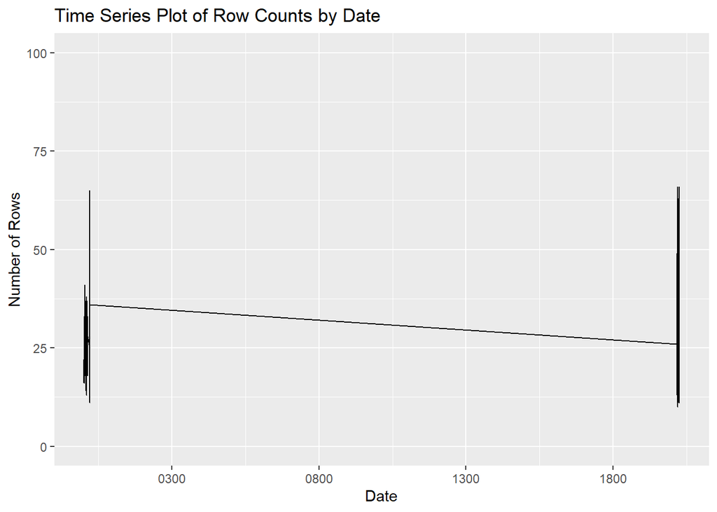

```r
myData$date2 <- as.Date(myData$date)

date_counts <- myData%>%
  group_by(date2) %>%
  summarise(count = n())

ggplot(date_counts, aes(x = date2, y = count)) +
  geom_line() +
  labs(x = "Date", y = "Number of Rows", title = "Time Series Plot of Row Counts by Date") + ylim(0,100)
```

Woah Nellie! Those are years on teh x axis, and something is super wrong with our date variable! The first few rows looked good, but this graph is terrible! It is very possibly an issue with inconsistent formatting.

Let’s start by isolating cases where the raw date does not match this one `myData$date2 <- as.Date(myData$date)`:

```r
dateTemp <- myData %>%
  select(date,date2) %>%
  mutate(date = as.character(date),
         date2 = as.character(date2)) %>%
  distinct()

dateTemp <- subset(dateTemp, date != date2, na.rm = T)

dateTemp
```

```
##            date      date2
## 132  01-09-2022 0001-09-20
## 137  01-12-2022 0001-12-20
## 138  01-10-2022 0001-10-20
## 140  01-06-2022 0001-06-20
## 141  01-04-2022 0001-04-20
## 142  01-07-2022 0001-07-20
## 143  01-05-2022 0001-05-20
## 145  01-03-2022 0001-03-20
## 149  01-11-2022 0001-11-20
## 150  01-08-2022 0001-08-20
## 151  01-02-2022 0001-02-20
## 155  01-01-2022 0001-01-20
## 332  02-02-2022 0002-02-20
## 333  02-07-2022 0002-07-20
```

[output cut: 130 more lines]

This shows us where some encodings are wrong. In this case, the 2022 data was in mdy form instead of ymd. So converting the whole string to ymd was wrong. There are multiple ways to clean this. The structure inconsistency is simple enough here that I think this way will be easiest:

```r
rowsToModify <- grep("-2022",myData$date)

myData$date[rowsToModify] <- gsub("-2022","",myData$date[rowsToModify])

myData$date[rowsToModify] <- paste0("2022-",myData$date[rowsToModify])
```

Let’s also just check the unique year values of the date variable after this change.

```r
sort(unique(year(myData$date)))
```

```
## [1]   20 2018 2019 2021 2022 2023 2024
```

That is weird. If you dig in a little further, you will see that all of the 2020 dates were messed up and recorded as the year 0020. It might not always be so easy to fix messy dates. They can get messed up in so many ways.

```r
myData$date <- gsub("0020","2020",myData$date)

myData$date <- ymd(myData$date)
```

It is hard to know what is going on with our dates, but maybe we should just check how many rows of data are on each date. I would like to see some consistency or pattern, without major holes or absurd spikes. (and, going back to the first graph, no dates from the 1st century). And I see consistently filled dates with some sort of seasonal pattern. I am going to leave dates alone for now.

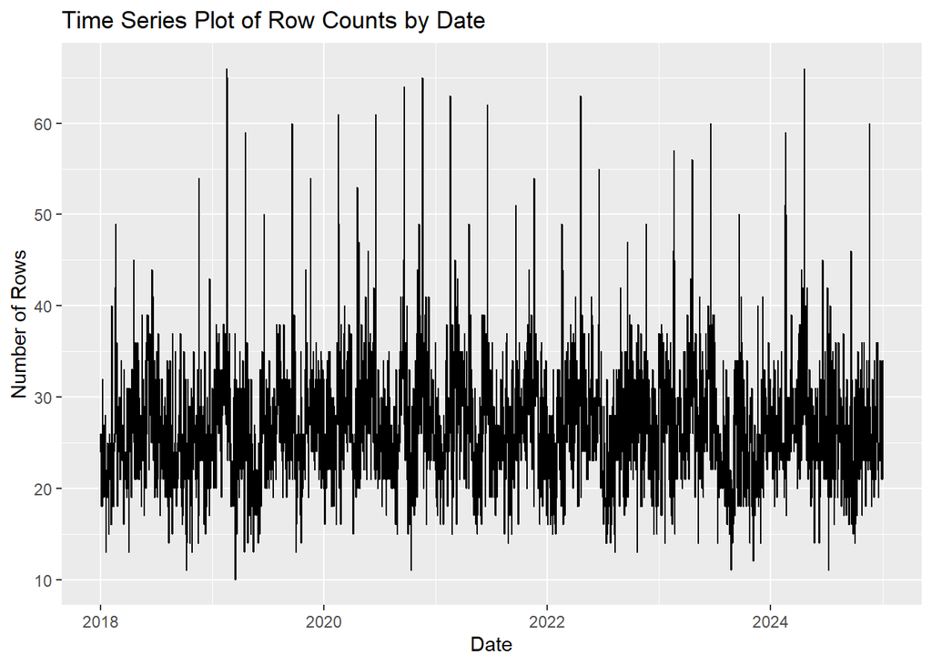

```r
date_counts <- myData%>%
  group_by(date) %>%
  summarise(count = n())

ggplot(date_counts, aes(x = date, y = count)) +
  geom_line() +
  labs(x = "Date", y = "Number of Rows", title = "Time Series Plot of Row Counts by Date")
```

## Other categorical variables

Let’s check the other categorical variables, too. This data set is small enough, we can take a simple approach and check unique values. In my experience, you will often find annoying little errors in these.

### Brand

We need some domain knowledge here. For this project, know that there are 9 brands, labeled brand01, brand02, … brand09. Our data set, however, has 75 unique values in the brand column. Let’s take a look.

```r
sort(unique(myData$brand))
```

```
##  [1] "# brnd01"          "# brnd02"          "# brnd03"
##  [4] "# brnd04"          "# brnd05"          "# brnd06"
##  [7] "# brnd08"          "# brnd09"          "br code: # brnd02"
## [10] "br code: # brnd03" "br code: # brnd04" "br code: # brnd05"
## [13] "br code: # brnd06" "br code: # brnd07" "br code: # brnd08"
## [16] "br code: # brnd09" "br code: brand 01" "br code: brand 02"
## [19] "br code: brand 03" "br code: brand 04" "br code: brand 05"
## [22] "br code: brand 06" "br code: brand 07" "br code: brand 08"
## [25] "br code: brand 09" "br code: brand01"  "br code: brand02"
## [28] "br code: branD02"  "br code: brand03"  "br code: branD03"
## [31] "br code: brand04"  "br code: brand05"  "br code: branD05"
## [34] "br code: brand06"  "br code: branD06"  "br code: brand07"
## [37] "br code: branD07"  "br code: brand08"  "br code: brand09"
## [40] "br code: branD09"  "brand 01"          "brand 02"
## [43] "brand 03"          "brand 04"          "brand 05"
## [46] "brand 06"          "brand 07"          "brand 08"
## [49] "brand 09"          "brand01"           "branD01"
## [52] "BRAND01"           "brand02"           "BRAND02"
## [55] "brand03"           "branD03"           "BRAND03"
## [58] "brand04"           "branD04"           "BRAND04"
## [61] "brand05"           "branD05"           "BRAND05"
## [64] "brand06"           "branD06"           "BRAND06"
## [67] "brand07"           "branD07"           "BRAND07"
## [70] "brand08"           "branD08"           "BRAND08"
## [73] "brand09"           "branD09"           "BRAND09"
```

Well that is annoying! Some are misspelled. Some have weird little prefixes. Some are lower case and some are upper case. Some have spaces and some don’t. Imagine a bunch of eople in different offices through the company, all writing the same thing in different ways. It happens!

```r
myData$brand <- tolower(myData$brand) #everything to lower case

# remove patterns we do not like and replace them with patters we do like.
myData$brand <- gsub("br code: ", "", myData$brand)

myData$brand <- gsub(" ", "", myData$brand)

myData$brand <- gsub("brnd","brand",myData$brand)

myData$brand <- gsub("#","",myData$brand)

sort(unique(myData$brand))
```

```
## [1] "brand01" "brand02" "brand03" "brand04" "brand05" "brand06" "brand07"
## [8] "brand08" "brand09"
```

### Segment

Market segments look fine. The data is made up, so we don’t know what A, B, or C mean, but the are consistently labeled.

```r
# Check for inconsistent formatting
unique_segments <- unique(myData$segment)

print(sort(unique_segments))
```

```
## [1] "A" "B" "C"
```

### zone

```r
unique_zones <- unique(myData$zone)

print(unique_zones)
```

```
##  [1] "south"   "central" "east"    "north"   "west"    "SOUTH"   "CENTRAL"
##  [8] "EAST"    "NORTH"   "WEST"
```

```r
myData$zone <- tolower(myData$zone)

unique(myData$zone)
```

```
## [1] "south"   "central" "east"    "north"   "west"
```

### region

```r
unique_regions <- unique(myData$region)

print(unique_regions)
```

```
##   [1] "region15"    "region07"    "region04"    "region05"    "region14"
##   [6] "region18"    "region03"    "region09"    "region16"    "region11"
##  [11] "region12"    "region13"    "region 13"   "region02"    "region10"
##  [16] "region17"    "region01"    "region06"    "region08"    "region 10"
##  [21] "region19"    "region20"    "region21"    "region 21"   "region22"
##  [26] "region23"    "region24"    "region 22"   "region 12"   "region 24"
##  [31] "region 18"   "region 14"   "region 05"   "region 01"   "region 02"
##  [36] "region 20"   "region 03"   "region 17"   "region 19"   "rregion20"
##  [41] "REGION15"    "REGION07"    "REGION04"    "REGION05"    "REGION14"
##  [46] "REGION18"    "REGION03"    "REGION09"    "REGION16"    "REGION11"
##  [51] "REGION12"    "REGION13"    "REGION02"    "REGION10"    "REGION17"
##  [56] "REGION01"    "REGION06"    "REGION08"    "REGION19"    "REGION20"
##  [61] "REGION21"    "REGION22"    "REGION23"    "REGION24"    "# region15"
##  [66] "# region07"  "# region04"  "# region05"  "# region14"  "# region18"
##  [71] "# region03"  "# region09"  "# region16"  "# region11"  "# region12"
##  [76] "# region13"  "# region02"  "# region10"  "# region17"  "# region01"
##  [81] "# region 03" "# region06"  "# region08"  "# region 12" "# region 15"
##  [86] "# region19"  "# region20"  "# region21"  "# region 21" "# region22"
##  [91] "# region23"  "# region24"  "# region 01" "# region 20" "# region 24"
##  [96] "# region 07" "# region 04" "# region 09" "# region 06" "# region 05"
## [101] "# region 10" "# region 16" "region 11"   "region 23"   "region 04"
## [106] "region 07"   "region 08"   "region 15"   "region 06"   "# region 18"
## [111] "# region 02" "# region 13" "region 09"   "region 16"   "# region 22"
## [116] "# region 17" "# region 11" "regoin02"    "# region 14" "# region 19"
## [121] "# region 08" "rregion22"   "rregion02"   "# regoin09"  "# region 23"
## [126] "rregion04"   "# regoin18"  "# rregion14" "# regoin04"  "regoin13"
```

Another mess!

```r
myData$region <- gsub(" ","",myData$region)
myData$region <- gsub("#","",myData$region)
myData$region <- toupper(myData$region)
myData$region <- gsub("REGOIN","REGION",myData$region)
myData$region <- gsub("RREGION","REGION",myData$region)
myData$region <- tolower(myData$region)

sort(unique(myData$region))
```

```
##  [1] "region01" "region02" "region03" "region04" "region05" "region06"
##  [7] "region07" "region08" "region09" "region10" "region11" "region12"
## [13] "region13" "region14" "region15" "region16" "region17" "region18"
## [19] "region19" "region20" "region21" "region22" "region23" "region24"
```

### customerID

```r
unique_customerID <- unique(myData$customerID)

print(unique_customerID)
```

```
##   [1] "CID_51"  "CID_8"   "CID_49"  "CID_89"  "CID_37"  "51"      "8"
##   [8] "49"      "89"      "37"      "65"      "72"      "20"      "66"
##  [15] "13"      "CID_65"  "CID_72"  "CID_20"  "CID_66"  "CID_13"  "91"
##  [22] "35"      "36"      "CID_91"  "CID_35"  "CID_36"  "67"      "77"
##  [29] "47"      "7"       "106"     "100"     "63"      "33"      "CID_67"
##  [36] "CID_77"  "CID_47"  "CID_7"   "CID_106" "CID_100" "CID_63"  "CID_33"
##  [43] "CID_10"  "CID_113" "CID_98"  "CID_78"  "CID_29"  "CID_69"  "CID_92"
##  [50] "CID_6"   "CID_16"  "CID_9"   "CID_45"  "CID_101" "CID_58"  "10"
##  [57] "113"     "98"      "78"      "29"      "69"      "92"      "6"
##  [64] "16"      "9"       "45"      "101"     "58"      "12"      "114"
##  [71] "41"      "82"      "CID_12"  "CID_114" "CID_41"  "CID_82"  "CID_26"
##  [78] "CID_50"  "CID_118" "CID_55"  "CID_60"  "26"      "50"      "118"
##  [85] "55"      "60"      "22"      "CID_22"  "38"      "CID_38"  "76"
##  [92] "90"      "14"      "CID_76"  "CID_90"  "CID_14"  "103"     "88"
##  [99] "17"      "74"      "48"      "CID_103" "CID_88"  "CID_17"  "CID_74"
```

[output cut: 21 more lines]

I don’t want to accidentally treat these like numbers in the future, so I am going to opt to keep “CID_” on them. I want it on all of them. This is not required. As long as R thins it is a character, it is fine. This is just a preference to help with recognizing the data.

This code tests whether the customerID begins with “CID_”, and if it doesn’t, it adds it.

```r
myData$customerID2 <- ifelse(grepl("^CID_", myData$customerID), myData$customerID, paste0("CID_", myData$customerID))
```

Don’t forget, though, that we had NA missing values, that are stored as “CID_NA” now.

In practice, you will need context to know what to do with these. It is not numeric, so it cannot be imputed. You could leave the CID_NA tag as a catch-all bin for unlabeled customers. Or you could drop those values from the data set. Or you could try to do something fancy. We’ll just leave this as is. CID_NA will be the value we use to describe unidentified customers.

```r
# Summary statistics
summary(myData)
```

```
##     brand             segment              zone              region
##  Length:68982       Length:68982       Length:68982       Length:68982
##  Class :character   Class :character   Class :character   Class :character
##  Mode  :character   Mode  :character   Mode  :character   Mode  :character
##
##
##
##
##   customerID          listPrice          discount        salesPrice
##  Length:68982       Min.   :  189.3   Min.   :-0.287   Min.   :    150
##  Class :character   1st Qu.:  585.8   1st Qu.:-0.168   1st Qu.:    514
##  Mode  :character   Median :  876.2   Median :-0.111   Median :    756
##                     Mean   : 2373.5   Mean   :-0.123   Mean   :   3610
##                     3rd Qu.: 2869.3   3rd Qu.:-0.057   3rd Qu.:   2632
##                     Max.   :13198.7   Max.   :-0.057   Max.   :3298259
##                     NA's   :4688      NA's   :8212     NA's   :4688
##      volume               date                date2
##  Min.   :0.000e+00   Min.   :2018-01-01   Min.   :0001-01-20
##  1st Qu.:1.277e+03   1st Qu.:2019-10-21   1st Qu.:2018-03-10
##  Median :8.026e+03   Median :2021-06-28   Median :2019-10-29
##  Mean   :4.604e+06   Mean   :2021-07-04   Mean   :1574-02-05
##  3rd Qu.:1.346e+04   3rd Qu.:2023-03-30   3rd Qu.:2023-05-18
##  Max.   :2.560e+11   Max.   :2024-12-31   Max.   :2024-12-31
##  NA's   :179                              NA's   :5964
##  customerID2
##  Length:68982
##  Class :character
##  Mode  :character
##
##
##
##
```

```r
# Count missing values per variable
missing_values <- colSums(is.na(myData))
missing_values
```

```
##       brand     segment        zone      region  customerID   listPrice
##           0           0           0           0         550        4688
##    discount  salesPrice      volume        date       date2 customerID2
##        8212        4688         179           0        5964           0
```

```r
print(paste0("There are ",nrow(myData), " rows in the data. This is how many NA values exist by variable:"))
```

```
## [1] "There are 68982 rows in the data. This is how many NA values exist by variable:"
```

```r
# Display only columns with missing values
missing_values[missing_values > 0]
```

```
## customerID  listPrice   discount salesPrice     volume      date2
##        550       4688       8212       4688        179       5964
```

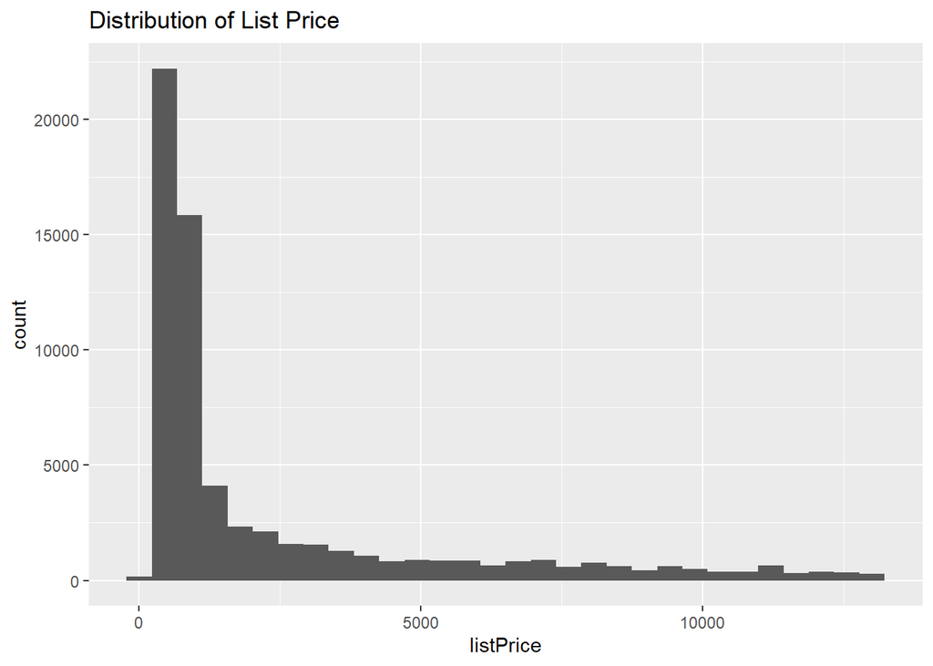

```r
# Visualize potential outliers
ggplot(myData, aes(x = listPrice)) +
  geom_histogram() +
  ggtitle("Distribution of List Price")
```

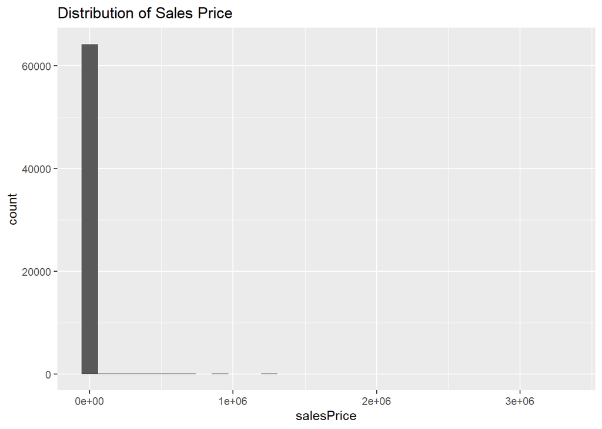

```r
ggplot(myData, aes(x = salesPrice)) +
  geom_histogram() +
  ggtitle("Distribution of Sales Price")
```

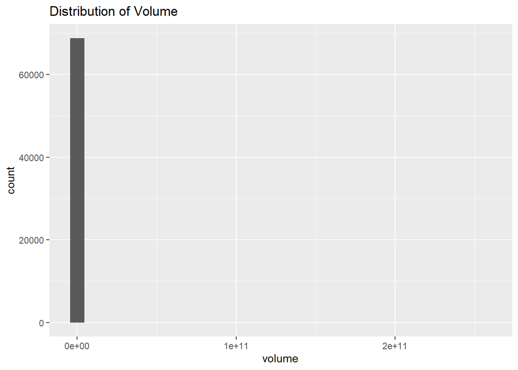

```r
ggplot(myData, aes(x = volume)) +
  geom_histogram() +
  ggtitle("Distribution of Volume")
```

```r
# Check for duplicates
duplicate_rows <- myData %>%
  count(brand, zone, region, customerID, listPrice, discount, salesPrice, volume, date) %>%
  filter(n > 1)

print(duplicate_rows)
```

```
##  [1] brand      zone       region     customerID listPrice  discount
##  [7] salesPrice volume     date       n
## <0 rows> (or 0-length row.names)
```

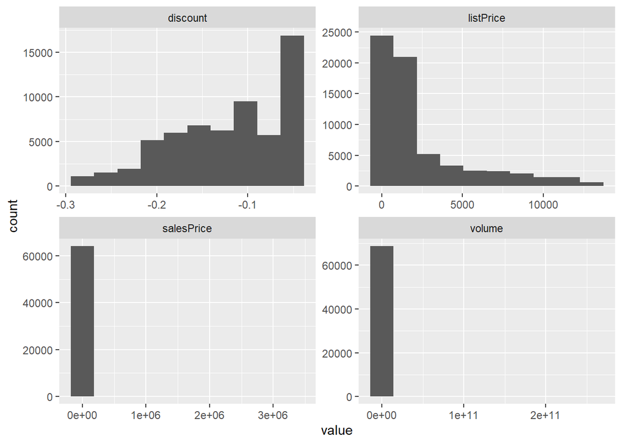

```r
# Histograms for numerical variables
myData %>%
  select(where(is.numeric)) %>%  # Select numeric columns
  pivot_longer(cols = everything()) %>%
  ggplot(aes(x = value)) +
  geom_histogram(bins = 10) +
  facet_wrap(~name, scales = "free")
```

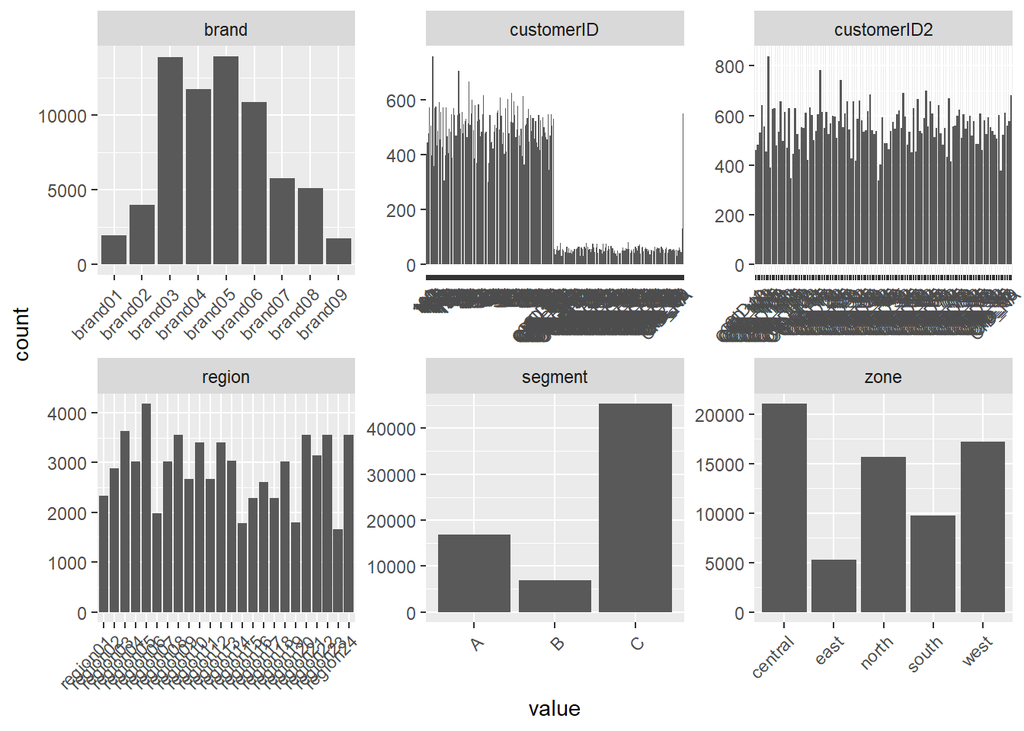

```r
# Bar charts for categorical variables
myData %>%
  select(where(is.character)) %>%  # Select character columns
  pivot_longer(cols = everything()) %>%
  ggplot(aes(x = value)) +
  geom_bar() +
  facet_wrap(~name, scales = "free") +
  theme(axis.text.x = element_text(angle = 45, hjust = 1))  # Rotate x-axis labels
```